# Indice de Calidad de Datos Ces Post Venta

## 4.2 Analisis del Nivel de Completitud en los Datos

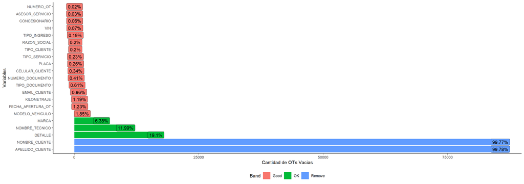

**Insights:**

- Hay OTs donde no se registrado el dato de correo, VIN, numero documento, placa.
- Hay un nivel significativo de OTs ~12% donde no se registro el nombre del tecnico que atendio el vehiculo.
- Los datos como el nombre y apellido del cliente estan casi vacios(~100%) en todos los concesionarios.

## 4.3 Analisis de VIN, NUM. DOC., PLACA en los concesionarios

### Analisis VIN

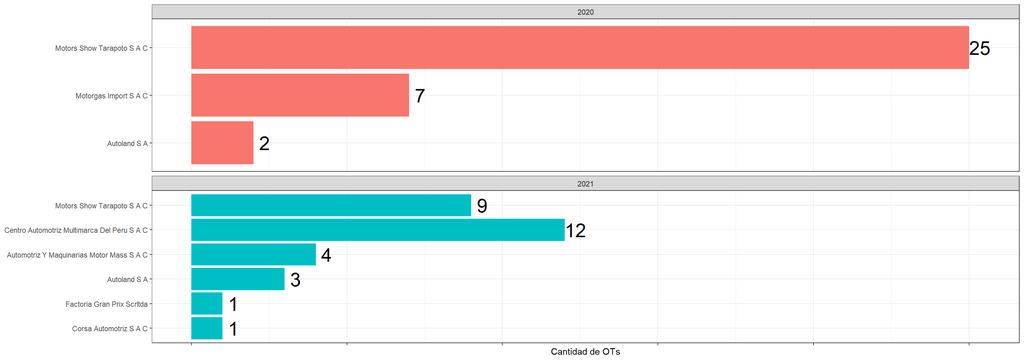

### Analisis NUM. DOC.

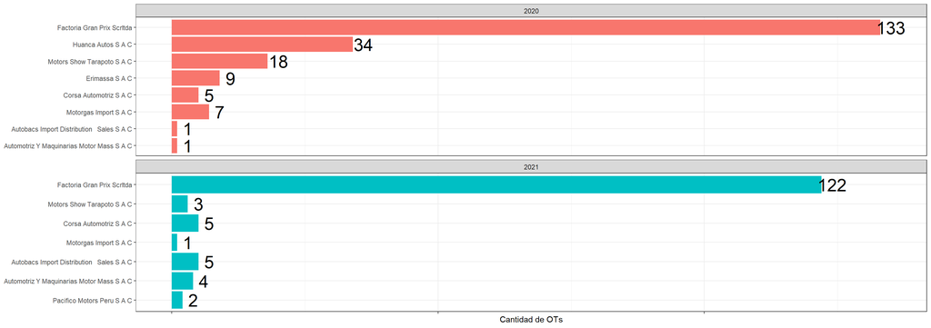

### Analisis PLACA

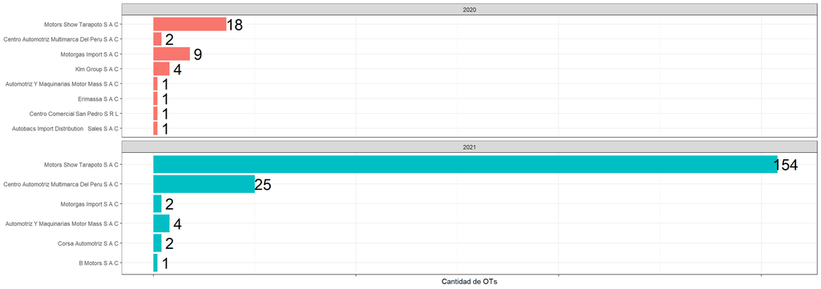

## 4.4 Distribucion de OT por concesionario

### Metodologia

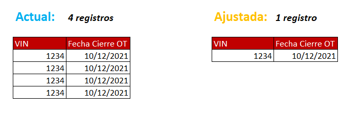

### Analisis

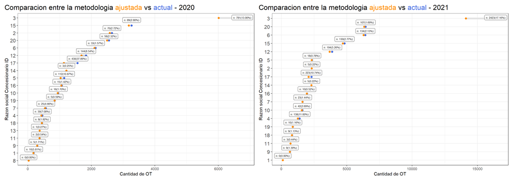

### Diccionario de Concesionarios ID

| razonsocial_concesionario_id | razonsocial_concesionario |
| --- | --- |
| 1 | Autobacs Import Distribution Sales S A C |
| 2 | Autoland S A |
| 3 | Automotores Pakatnamu S A C |
| 4 | Automotores Pakatnamu Selva S A C |
| 5 | Automotriz Y Maquinarias Motor Mass S A C |
| 6 | B Motors S A C |
| 7 | Centro Automotriz Multimarca Del Peru S A C |
| 9 | Corsa Automotriz S A C |
| 10 | Erimassa S A C |
| 11 | Factoria Gran Prix Scrltda |

[output cut: 8 more lines]

## 4.5 Frecuencia de VINs por Correo y Concesionario

- En el 2020 la cantidad de autos relacionados con un correo va desde 1 a 229
- En el 2021 la Cantidad de Autos relacionados con un correo va desde 1 a 794.

  Datos de Correo y concesionario con maxima cantidad de autos relacionados

  | Año | Email | Concesionario |
  | --- | --- | --- |
  | 2020 | eirigoins/@automotorespakatnamu.com | automotores pakatnamu s.a.c. |
  | 2021 | eirigoins/@automotorespakatnamu.com | automotores pakatnamu s.a.c. |

### General

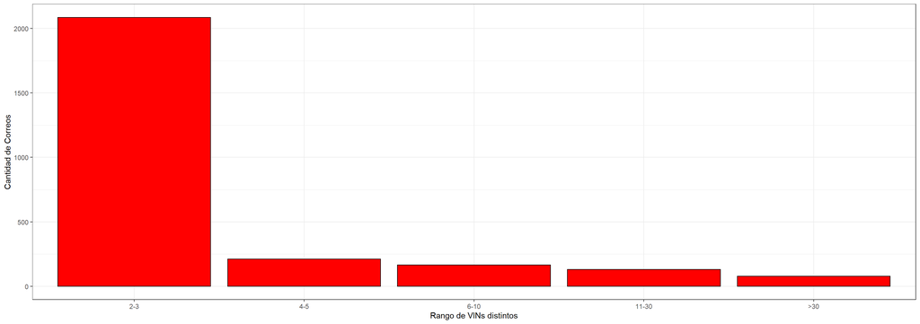

### 2020

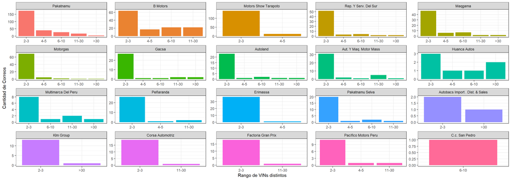

### 2021

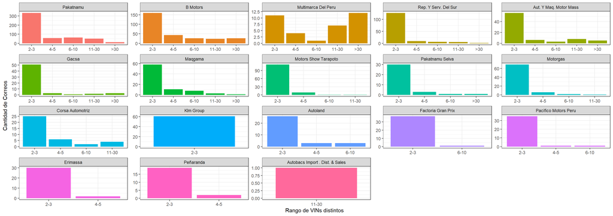

# 5. Calidad de Datos

## 5.1 Calidad en Variable DNI y Tipo Documento

### TIPO DOCUMENTO

La calidad del Tipo de Documento esta a un 99.39%, el resto tiene datos erroneos o mal escritos.

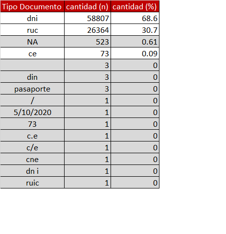

### DNI

Distribucion de Longitudes segun tipo Doumento

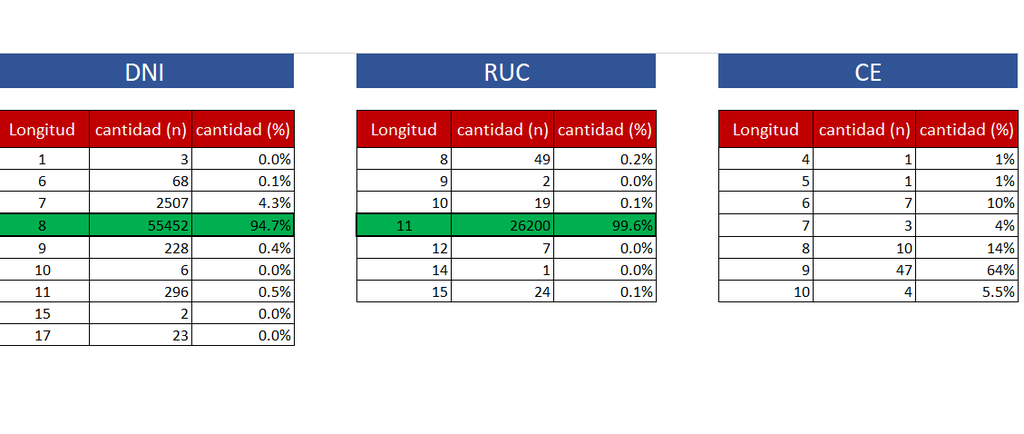

[Informacion de la longitud por tipo de documento](http://www2.sunat.gob.pe/pdt/pdtModulos/independientes/p695/TipoDoc.htm)

## 5.2 Calidad en Celular del Cliente

La longitud del celular registrado va desde 0 o sin registro hasta 29 digitos.

Distribucion de la cantidad de digitos del celular:

| Longitud del Celular | Cantidad(n) | Cantidad(%) |
| --- | --- | --- |
| 9 | 82444 | 96.43 |
| <>9 | 3050 | 3.57 |

- Del total de celulares registrados un 3.5%(3050) de los registros tiene una longitud distinta a 9.

## 5.3 Calidad en Marca

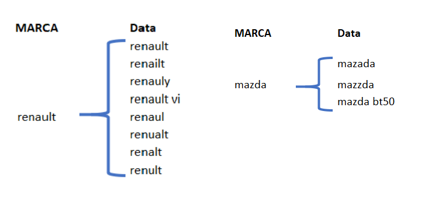

- Se observa que no se esta registrando correctamente la MARCA del vehiculo.

## 5.3 Calidad en Kilometraje

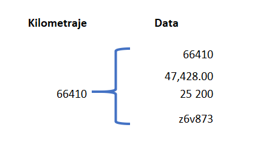

- Del 100% de registros en kilometraje 7.4%(6390) no estan bien registrados o inclusive se registraron placas por error.